# Satellite Image Classification

Matheus Schmitz  
[LinkedIn](https://www.linkedin.com/in/matheusschmitz/)  
[Github Portfolio](https://matheus-schmitz.github.io/)

### Project Definition

Artificial Intelligence for Satellite Image Classification

Every minute, the world loses an area of forest the size of 48 football fields. And deforestation in the Amazon Basin accounts for the largest share, contributing to reduced biodiversity, habitat loss, climate change and other devastating effects. However, better data on the location of deforestation and human encroachment on forests can help governments and stakeholders respond more quickly and effectively.

Planet, the designer and builder of the Earth's largest constellation of imaging satellites, will soon be collecting daily images of the entire Earth's surface at a resolution of 3-5 meters. Although considerable research has been devoted to tracking changes in forests, it typically relies on Landsat (30 meters) or MODIS (250 meters) resolution images. This limits its effectiveness in areas where small-scale deforestation or forest degradation predominates.

Furthermore, these existing methods generally cannot differentiate forest degradation between human causes and natural causes. Higher resolution images are exceptionally good at this, but robust methods have not yet been developed for Planet imaging.

> In this work, the goal is to classify satellite images with different atmospheric conditions and land cover/land use classes.

### Dataset

Datasets with satellite images are available for free on Kaggle:

https://www.kaggle.com/c/planet-understanding-the-amazon-from-space/data

Images are provided in two formats: .tif and .jpg

The .tif files offer better resolution quality, but the final dataset is almost 40 GB. Therefore, for the purpose of this project (which is to study CNNs) we will use images in .jpg format totaling just over 1 GB.

Although images can be extracted from the link above, we've already made it for you and organized it on Titan (DSA server). More details when we upload the images.

Below is a description of the format of the images.

The images have been split into chips, like this one below.

[figure not shown]

The chips were derived from full-frame analysis performed by Planet, using the 4-band satellites in synchronous orbit to the sun (SSO) and the International Space Station (ISS). The chipset uses the GeoTiff format and each one contains four bands of data: red, green, blue and infrared. The satellites' specific spectral response can be found in Planet's documentation. Each of these channels is in 16-bit digital number format and meets Planet four-band orthoanalytic scene product specifications.

The chips are also available in JPG format, which we will use here in the project.

**Dataset Creation**

In order to assemble this dataset, an initial specification of the phenomena to be found and included in the final dataset was established. From this initial specification, a "wish list" of scenes was created in which an approximate number of scenes needed to obtain a sufficient number of chips to demonstrate the phenomenon were included.

This initial set of scenes was painstakingly collected by the Planet Berlin team using Planet Explorer. In total, this initial set of scenes was approximately 1600 and covered an area of thirty million hectares.

This initial set of scenes was processed using a custom processor to create the 4-band jpg and tiff chips. Any chip that did not have a full four-band product was omitted. This initial set of over 150,000 chips was divided into two sets, a "hard" and an "easy".

The easy set contained scenes that the Berlin team identified as having easier-to-identify labels, such as **primary forest, agriculture, housing, roads, water and cloud conditions**. The most difficult set of data was derived from scenes in which the Berlin team had selected for **cultivation, slash and burn cropland, deforestation, mining and other phenomena**.

The chips were labeled using the [Crowd Flower](https://appen.com/) platform and a mix of collective labor and teams from Berlin and San Francisco. While the utmost care has been taken to obtain a large, well-labeled dataset, not all of the labels in our dataset are correct. Governments around the world have a large number of highly trained analysts to review images and cannot always agree on what is present in a given satellite image.

Also, the commonly prescribed approach to tagging data in the GIS community is to use real data to tag scenes, which is expensive and time-consuming. With that in mind, the data has a reasonably high signal to noise ratio and is sufficient for training. Given the ease and convenience of labeling multiple files, a large, relatively inexpensive, and quickly labeled dataset is believed to be better than a small, more definitive, but less diverse dataset.

The company [SCCON](https://www.sccon.com.br/) also participated in the project.

**Class Tags**

The class labels for this task were chosen in collaboration with the Planet team and represent a reasonable subset of phenomena of interest in the Amazon basin. The labels can be divided into three groups: atmospheric conditions, common land cover/land use phenomena and rare land cover/land use phenomena.

- Each chip (patch) will have one and potentially more than one atmospheric label and zero or more common and rare labels.
- Chips labeled as cloudy must not have other labels, but there may be labeling errors.

[figure not shown]

### Loading Packages

```python
!nvidia-smi
```

```
Sun May  3 22:00:11 2020
+-----------------------------------------------------------------------------+
| NVIDIA-SMI 440.64.00    Driver Version: 440.64.00    CUDA Version: 10.2     |
|-------------------------------+----------------------+----------------------+
| GPU  Name        Persistence-M| Bus-Id        Disp.A | Volatile Uncorr. ECC |
| Fan  Temp  Perf  Pwr:Usage/Cap|         Memory-Usage | GPU-Util  Compute M. |
|===============================+======================+======================|
|   0  TITAN X (Pascal)    On   | 00000000:05:00.0 Off |                  N/A |
| 23%   38C    P8     9W / 250W |    114MiB / 12194MiB |      0%      Default |
+-------------------------------+----------------------+----------------------+
|   1  GeForce GTX 108...  On   | 00000000:09:00.0 Off |                  N/A |
| 23%   34C    P8     9W / 250W |      2MiB / 11178MiB |      0%      Default |
+-------------------------------+----------------------+----------------------+
|   2  TITAN RTX           On   | 00000000:0B:00.0 Off |                  N/A |
| 40%   39C    P0    84W / 280W |      1MiB / 24220MiB |     31%      Default |
+-------------------------------+----------------------+----------------------+

+-----------------------------------------------------------------------------+
| Processes:                                                       GPU Memory |
|  GPU       PID   Type   Process name                             Usage      |
|=============================================================================|
|    0      1596      G   /usr/lib/xorg/Xorg                            39MiB |
|    0      1633      G   /usr/bin/gnome-shell                          72MiB |
+-----------------------------------------------------------------------------+
```

```python
# Imports para manipulação e visualização de dados
import os
import sys
import cv2
import csv
import math
import time
import pickle
import numpy as np
import pandas as pd
import seaborn as sns
import matplotlib.pyplot as plt
import matplotlib.image as mpimg
from os import listdir
from tqdm import tqdm
from PIL import Image
from mpl_toolkits.axes_grid1 import ImageGrid

# Deep Learning
import tensorflow as tf
import keras
from tensorflow.keras.preprocessing.image import ImageDataGenerator
from tensorflow.keras.backend import clear_session
from keras import backend as K
from keras.models import Sequential
from keras.layers import Dense, Dropout, Flatten
from keras.layers import Conv2D, MaxPool2D
from keras.optimizers import Adam
from keras.callbacks import ModelCheckpoint, Callback, ReduceLROnPlateau

# Evaluate metrics
import sklearn
from sklearn.utils import shuffle
from sklearn.model_selection import KFold
from sklearn.model_selection import train_test_split

# Disable warnings
import sys
import warnings
import matplotlib.cbook
if not sys.warnoptions:
    warnings.simplefilter("ignore")
warnings.simplefilter(action='ignore', category=FutureWarning)
warnings.filterwarnings("ignore", category=FutureWarning)
warnings.filterwarnings("ignore", category=matplotlib.cbook.mplDeprecation)
%matplotlib inline
```

```python
# Package versions
# Using Python 3.7.6
%reload_ext watermark
%watermark --iversions
```

```
pandas     1.0.3
PIL.Image  7.0.0
cv2.cv2    4.2.0
seaborn    0.10.0
sklearn    0.22.2
keras      2.3.1
matplotlib 3.2.1
csv        1.0
numpy      1.18.2
tensorflow 2.1.0
Data Science Academy
```

## Checking Hardware Available on the Server

```python
# Lista todos os dispositivos disponiveis
from tensorflow.python.client import device_lib
print(device_lib.list_local_devices())
```

[output not shown]

[output cut: 20 more lines]

```
device_type: "GPU"
memory_limit: 10910800282
locality {
  bus_id: 1
  links {
    link {
      device_id: 1
      type: "StreamExecutor"
      strength: 1
    }
  }
}
incarnation: 12991201856458469678
physical_device_desc: "device: 2, name: GeForce GTX 1080 Ti, pci bus id: 0000:09:00.0, compute capability: 6.1"
]
```

```python
import tensorflow as tf
print("Número Disponível de GPUs: ", len(tf.config.experimental.list_physical_devices('GPU')))
```

```
Número Disponível de GPUs:  3
```

```python
# List the code for each GPU
tf.config.list_physical_devices('GPU')
```

```
[PhysicalDevice(name='/physical_device:GPU:0', device_type='GPU'),
 PhysicalDevice(name='/physical_device:GPU:1', device_type='GPU'),
 PhysicalDevice(name='/physical_device:GPU:2', device_type='GPU')]
```

## Loading Images

```python
# Directory with images
imagens_treino = '/media/datasets/DeepLearningI/Cap08/CNN02/train-jpg'
imagens_teste = '/media/datasets/DeepLearningI/Cap08/CNN02/test-jpg'
```

```python
# Directory with labels
etiquetas_treino = '/media/datasets/DeepLearningI/Cap08/CNN02/labels/train_v2.csv'
```

```python
# Output directory
classificacao_etiquetas_teste = 'arquivos/resultado.csv'
```

## Preparing Data

```python
# Load csvs to DataFrames
dados_treino = pd.read_csv(etiquetas_treino)
dados_teste = pd.read_csv(classificacao_etiquetas_teste)
```

```python
# Inspect DataFrames
dados_treino.head()
```

|  | image_name | tags |
| --- | --- | --- |
| 0 | train_0 | haze primary |
| 1 | train_1 | agriculture clear primary water |
| 2 | train_2 | clear primary |
| 3 | train_3 | clear primary |
| 4 | train_4 | agriculture clear habitation primary road |

```python
# Shape
dados_treino.shape
```

```
(40479, 2)
```

```python
# Inspect DataFrames
dados_teste.head()
```

|  | image_name | tags |
| --- | --- | --- |
| 0 | test_0 | primary clear agriculture road water |
| 1 | test_1 | primary clear agriculture road water |
| 2 | test_2 | primary clear agriculture road water |
| 3 | test_3 | primary clear agriculture road water |
| 4 | test_4 | primary clear agriculture road water |

```python
# Shape
dados_teste.shape
```

```
(61191, 2)
```

```python
# Add the .jpg extension to image names
dados_treino['image_name'] = dados_treino['image_name'].astype(str) + '.jpg'
dados_teste['image_name'] = dados_teste['image_name'].astype(str) + '.jpg'
```

```python
# Convert labels from string to list of strings
dados_teste['tags'] = dados_teste['tags'].apply(lambda x: x.split(' '))
```

```python
# View DataFrame
print("\nImagens de Treino:\n")
dados_treino.head()
```

```
Imagens de Treino:
```

|  | image_name | tags |
| --- | --- | --- |
| 0 | train_0.jpg | haze primary |
| 1 | train_1.jpg | agriculture clear primary water |
| 2 | train_2.jpg | clear primary |
| 3 | train_3.jpg | clear primary |
| 4 | train_4.jpg | agriculture clear habitation primary road |

```python
# View DataFrame
print("\nImagens de Teste (começo do arquivo):\n")
dados_teste.head()
```

```
Imagens de Teste (começo do arquivo):
```

|  | image_name | tags |
| --- | --- | --- |
| 0 | test_0.jpg | [primary, clear, agriculture, road, water] |
| 1 | test_1.jpg | [primary, clear, agriculture, road, water] |
| 2 | test_2.jpg | [primary, clear, agriculture, road, water] |
| 3 | test_3.jpg | [primary, clear, agriculture, road, water] |
| 4 | test_4.jpg | [primary, clear, agriculture, road, water] |

```python
# View DataFrame
print("\nImagens de Teste (final do arquivo):\n")
dados_teste.tail()
```

```
Imagens de Teste (final do arquivo):
```

|  | image_name | tags |
| --- | --- | --- |
| 61186 | file_9995.jpg | [primary, clear, agriculture, road, water] |
| 61187 | file_9996.jpg | [primary, clear, agriculture, road, water] |
| 61188 | file_9997.jpg | [primary, clear, agriculture, road, water] |
| 61189 | file_9998.jpg | [primary, clear, agriculture, road, water] |
| 61190 | file_9999.jpg | [primary, clear, agriculture, road, water] |

```python
# Shrink the test dataset size
dados_teste_final = dados_teste.iloc[:40479,]
```

```python
# Store the remaining test files apart
dados_teste_restante = dados_teste.iloc[40479:,]
```

```python
# Shape
dados_teste_final.shape
```

```
(40479, 2)
```

```python
# Shape
dados_teste_restante.shape
```

```
(20712, 2)
```

```python
# Delete the original dataset to reduce RAM usage
del dados_teste
```

## Train Test Split

```python
# Train-test split and convert to np.array
X_imagens_treino = np.array(dados_treino['image_name'].tolist())
X_imagens_treino.reshape((X_imagens_treino.shape[0], 1))
y_labels_treino = np.array(dados_treino['tags'].tolist())
```

```python
# X
X_imagens_treino
```

```
array(['train_0.jpg', 'train_1.jpg', 'train_2.jpg', ...,
       'train_40476.jpg', 'train_40477.jpg', 'train_40478.jpg'],
      dtype='<U15')
```

```python
# Shape
X_imagens_treino.shape
```

```
(40479,)
```

```python
# y
y_labels_treino
```

```
array(['haze primary', 'agriculture clear primary water', 'clear primary',
       ..., 'agriculture clear primary', 'agriculture clear primary road',
       'agriculture cultivation partly_cloudy primary'], dtype='<U92')
```

```python
# Shape
y_labels_treino.shape
```

```
(40479,)
```

```python
# There are 17 labels and each image has multiple labels

# Labels list
labels = []

# Loop through the labels and get all unique labels
for tag in dados_treino['tags'].values:
    labels_in_tag = tag.split(' ')
    for label in labels_in_tag:
        if label not in labels:
            labels.append(label)
```

```python
# Sort the labels
labels.sort()

# Print
print('\nClasses Únicas:', len(labels))
print('\nNomes das Classes:', labels)
```

```
Classes Únicas: 17

Nomes das Classes: ['agriculture', 'artisinal_mine', 'bare_ground', 'blooming', 'blow_down', 'clear', 'cloudy', 'conventional_mine', 'cultivation', 'habitation', 'haze', 'partly_cloudy', 'primary', 'road', 'selective_logging', 'slash_burn', 'water']
```

## Choosing Image Resolution for Training the Model

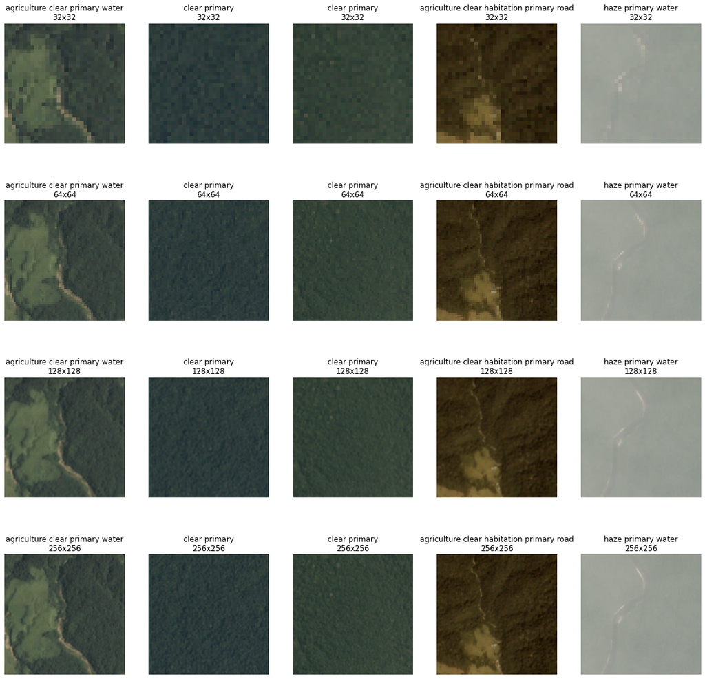

```python
# Loop through the images to check the quality of each resolution

# Figure size
plt.figure(figsize = (20, 20))

# List of resolutions
res = [32, 64, 128, 256]

# Number of images
num_imagens = 5

# All images have the same size. Resizing with OpenCV to evaluate resolutions.
for i in range(len(res)):
    for j in range(num_imagens):
        img = cv2.imread(os.path.join(imagens_treino, dados_treino['image_name'][j + 1]))
        img = cv2.resize(img, (res[i], res[i]))
        plt.subplot(len(res), num_imagens, i * num_imagens + j + 1)
        plt.imshow(cv2.cvtColor(img, cv2.COLOR_BGR2RGB))
        plt.title(dados_treino['tags'][j + 1] + "\n" + str(res[i]) + "x" + str(res[i]))
        plt.axis('off')

plt.show()
```

> The 128x128 images have good resolution and faster processing than the 256x256 images.

## Checking Label Distribution

```python
# Loop through train labels

# Dict to count label instances
labels_count = {}

# Loop
for tag in dados_treino['tags'].values:
    labels_in_tag = tag.split(' ')
    for label in labels_in_tag:
        if label in labels_count:
            labels_count[label] += 1
        else:
            labels_count[label] = 0
```

```python
# Extract min and max
min_label = min(labels_count, key = labels_count.get)
max_label = max(labels_count, key = labels_count.get)
```

```python
# Print
print(min_label + " é a classe com menor número de imagens: " + str(labels_count[min_label]))
print(max_label + " é a classe com maior número de imagens: " + str(labels_count[max_label]))
```

```
conventional_mine é a classe com menor número de imagens: 99
primary é a classe com maior número de imagens: 37512
```

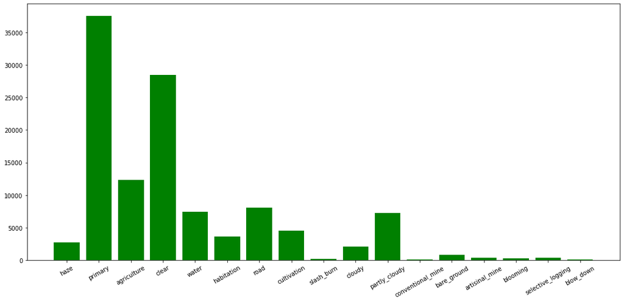

```python
# Figure size
plt.figure(figsize = (18, 8))

# Plot
plt.bar(range(len(labels_count)), list(labels_count.values()), align = 'center', color = 'green')
plt.xticks(range(len(labels_count)), list(labels_count.keys()), rotation = 30)
plt.show()
```

## Build Model

```python
# Function to extract the model's learning curve
def curva_aprendizado(modelo, key = 'accuracy', ylim = (0.8, 1.01)):
    plt.figure(figsize = (15,6))
    plt.plot(modelo.history[key])
    plt.plot(modelo.history['val_' + key])
    plt.title('Curva de Aprendizado do Modelo')
    plt.ylabel(key.title())
    plt.xlabel('Epoch')
    plt.ylim(ylim)
    plt.legend(['Treino', 'Teste'], loc = 'best')
    plt.show()
```

Let's create a function for the F-beta score and use it as a metric in validating our model. Scikit-learn has a function for this metric, but the idea is for you to understand what is being done and that's why we're creating ours. Here's the link to Scikit-learn:

https://scikit-learn.org/stable/modules/generated/sklearn.metrics.fbeta_score.html

```python
# F-Beta Score function
def fbeta_score(y_true, y_pred):
    beta_squared = 4
    tp = K.sum(y_true * y_pred) + K.epsilon()
    fp = K.sum(y_pred) - tp
    fn = K.sum(y_true) - tp
    precision = tp / (tp + fp)
    recall = tp / (tp + fn)
    result = (beta_squared + 1) * (precision * recall) / (beta_squared * precision + recall + K.epsilon())
    return result
```

```python
# Model hyperparameters

# Image dimensions
INPUT_SHAPE = (128, 128, 3)

# Batch Size
BATCH_SIZE = 128

# Dropout
DROPOUT_RATE = 0.1

# Number of epochs
EPOCHS = 25

# Learning rate
LR = 0.0001

# Decay rate
DECAY = 0.0001

# Number of folds for cross validation
NFOLDS = 5

# Number of each fold during training
# We start with 1 because the variable will be incremented inside the training loop
NUM_FOLD = 1

# Image classification threshold
# The sigmoid function delivers probabilities and we set the limit for one class or another
THRES = [0.2] * 17

# Directory to save models
PATH_MODELOS = 'modelos/'

# Directory to save files
PATH_ARQUIVOS = 'arquivos/'
```

```python
# CNN model architecture
def cria_modelo():

    model = Sequential([

        # First convolutional layer, with two sequential convolutions
        Conv2D(32, kernel_size = (3, 3), activation = 'relu', padding = 'same', input_shape = INPUT_SHAPE),
        Conv2D(32, kernel_size = (3, 3), activation = 'relu'),
        MaxPool2D(pool_size = (2, 2)),
        Dropout(DROPOUT_RATE),

        # Second convolutional layer, with two sequential convolutions
        Conv2D(64, kernel_size = (3, 3), activation = 'relu', padding = 'same'),
        Conv2D(64, kernel_size = (3, 3), activation = 'relu'),
        MaxPool2D(pool_size = (2, 2)),
        Dropout(DROPOUT_RATE),

        # Third convolutional layer, with two sequential convolutions
        Conv2D(128, kernel_size = (3, 3), activation = 'relu', padding = 'same'),
        Conv2D(128, kernel_size = (3, 3), activation = 'relu'),
        Conv2D(128, kernel_size = (3, 3), activation = 'relu'),
        MaxPool2D(pool_size = (2, 2)),
        Dropout(DROPOUT_RATE),

        # Fourth convolutional layer, with two sequential convolutions
        Conv2D(256, kernel_size = (3, 3), activation = 'relu', padding = 'same'),
        Conv2D(256, kernel_size = (3, 3), activation = 'relu'),
        Conv2D(256, kernel_size = (3, 3), activation = 'relu'),
        MaxPool2D(pool_size = (2, 2)),
        Dropout(DROPOUT_RATE),

        Flatten(),

        Dense(17, activation = 'sigmoid')
    ])

    # Adam optimizer
    optimizer = Adam(LR, decay = DECAY)

    return model
```

```python
# Create model
modelo = cria_modelo()
```

```python
# Clears the session and prints the model summary
clear_session()
modelo.summary()
```

```
Model: "sequential_1"
_________________________________________________________________
Layer (type)                 Output Shape              Param #
=================================================================
conv2d_1 (Conv2D)            (None, 128, 128, 32)      896
_________________________________________________________________
conv2d_2 (Conv2D)            (None, 126, 126, 32)      9248
_________________________________________________________________
max_pooling2d_1 (MaxPooling2 (None, 63, 63, 32)        0
_________________________________________________________________
dropout_1 (Dropout)          (None, 63, 63, 32)        0
_________________________________________________________________
conv2d_3 (Conv2D)            (None, 63, 63, 64)        18496
_________________________________________________________________
conv2d_4 (Conv2D)            (None, 61, 61, 64)        36928
_________________________________________________________________
max_pooling2d_2 (MaxPooling2 (None, 30, 30, 64)        0
_________________________________________________________________
dropout_2 (Dropout)          (None, 30, 30, 64)        0
_________________________________________________________________
conv2d_5 (Conv2D)            (None, 30, 30, 128)       73856
_________________________________________________________________
conv2d_6 (Conv2D)            (None, 28, 28, 128)       147584
_________________________________________________________________
conv2d_7 (Conv2D)            (None, 26, 26, 128)       147584
_________________________________________________________________
max_pooling2d_3 (MaxPooling2 (None, 13, 13, 128)       0
_________________________________________________________________
dropout_3 (Dropout)          (None, 13, 13, 128)       0
_________________________________________________________________
conv2d_8 (Conv2D)            (None, 13, 13, 256)       295168
_________________________________________________________________
conv2d_9 (Conv2D)            (None, 11, 11, 256)       590080
_________________________________________________________________
conv2d_10 (Conv2D)           (None, 9, 9, 256)         590080
_________________________________________________________________
max_pooling2d_4 (MaxPooling2 (None, 4, 4, 256)         0
_________________________________________________________________
dropout_4 (Dropout)          (None, 4, 4, 256)         0
_________________________________________________________________
flatten_1 (Flatten)          (None, 4096)              0
_________________________________________________________________
dense_1 (Dense)              (None, 17)                69649
=================================================================
Total params: 1,979,569
Trainable params: 1,979,569
Non-trainable params: 0
_________________________________________________________________
```

## Train Model with Cross-Validation

```python
# Empty list for the test predictions
y_teste = []
```

```python
# Number of folds
folds = KFold(n_splits = NFOLDS, shuffle = True, random_state = 1).split(X_imagens_treino, y_labels_treino)
```

```python
%%time

# Training loop with cross-validation
for train_index, val_index in folds:

    print("\nIniciando o Treinamento do Fold", NUM_FOLD)

    # Prepare train data
    X_train_files_fold = X_imagens_treino[train_index]
    y_train_fold = y_labels_treino[train_index]

    # Prepare validation data
    X_val_files_fold = X_imagens_treino[val_index]
    y_val_fold = y_labels_treino[val_index]

    # Convert to DataFrame
    train_df = pd.DataFrame(list(zip(X_train_files_fold, y_train_fold)), columns = ['image_name', 'tags'])
    val_df = pd.DataFrame(list(zip(X_val_files_fold, y_val_fold)), columns = ['image_name', 'tags'])

    # Get the labels
    train_df['tags'] = train_df['tags'].apply(lambda x: x.split(' '))
    val_df['tags'] = val_df['tags'].apply(lambda x: x.split(' '))

    print("\nDimensões dos Dados de Treino:", len(train_df))

    # Adjust train images
    # Based on: https://keras.io/preprocessing/image/
    train_datagen = ImageDataGenerator(rescale = 1./255,
                                       width_shift_range = 0.2,
                                       height_shift_range = 0.2,
                                       horizontal_flip = True,
                                       vertical_flip = True)

    # Adjust test images
    train_generator = train_datagen.flow_from_dataframe(train_df,
                                                        directory = imagens_treino,
                                                        x_col = 'image_name',
                                                        y_col = 'tags',
                                                        target_size = (INPUT_SHAPE[0], INPUT_SHAPE[1]), # 128 x 128
                                                        class_mode = 'categorical',
                                                        batch_size = BATCH_SIZE,
                                                        classes = labels,)

    print("\nDimensões dos Dados de Validação:", len(val_df))

    # Adjust valid images
    val_datagen = ImageDataGenerator(rescale = 1./255)

    # Prepare validation dataset
    val_generator = val_datagen.flow_from_dataframe(val_df,
                                                    directory = imagens_treino,
                                                    x_col = 'image_name',
                                                    y_col = 'tags',
                                                    target_size = (INPUT_SHAPE[0], INPUT_SHAPE[1]), # 128 x 128
                                                    class_mode = 'categorical',
                                                    batch_size = BATCH_SIZE,
                                                    classes = labels,)

    print("\nDimensões dos Dados de Teste:", len(dados_teste_final))

    # Adjust test images
    test_datagen = ImageDataGenerator(rescale = 1./255)

    # Prepare test dataset
    test_generator = test_datagen.flow_from_dataframe(dados_teste_final,
                                                      directory = imagens_teste,
                                                      x_col = 'image_name',
                                                      y_col = 'tags',
                                                      target_size = (INPUT_SHAPE[0], INPUT_SHAPE[1]), # 128 x 128
                                                      class_mode = 'categorical',
                                                      batch_size = BATCH_SIZE,
                                                      classes = labels,
                                                      shuffle = False,)

    # Clear session (free GPU memory)
    clear_session()

    # Create model
    modelo_cnn_satelite = cria_modelo()

    # Learning Rate and Adam Optinmizer
    adam = Adam(learning_rate = LR)

    # Loss functions
    func_loss = 'binary_crossentropy'

    # Compile model
    modelo_cnn_satelite.compile(optimizer = adam, loss = func_loss, metrics = [fbeta_score, 'accuracy'])

    # Path to save the model after each fold
    modelo_fold_salvo = os.path.join(PATH_MODELOS, 'pesos_fold_' + str(NUM_FOLD) + '.h5')

    # Callbacks to checkpoint the model and reduce learning rate on plateau
    # https://www.tensorflow.org/api_docs/python/tf/keras/callbacks/ReduceLROnPlateau
    callbacks = [ModelCheckpoint(modelo_fold_salvo,
                                 monitor = 'fbeta_score',
                                 save_best_only = True,
                                 mode = 'max'),
                 ReduceLROnPlateau(monitor = 'loss',
                                   factor = 0.1,
                                   patience = 3,
                                   mode = 'min',
                                   min_lr = 0.000001,
                                   verbose = 1)]

    # Trein model
    modelo_cnn_satelite.fit_generator(train_generator,
                                      epochs = EPOCHS,
                                      validation_data = val_generator,
                                      callbacks = callbacks)

    # Load model from disk
    modelo_cnn_satelite.load_weights(modelo_fold_salvo)

    # Predict
    print("\nModelo fazendo a classificação nos dados de teste. Seja paciente e aguarde...")
    previsao_teste = modelo_cnn_satelite.predict_generator(test_generator)

    # Store results
    y_teste.append(previsao_teste)

    # Go to next cross-validation fold
    print("\nTérmino do Fold ", NUM_FOLD, " da Validação Cruzada.")
    NUM_FOLD += 1

print("\nTreinamento Concluído.")
```

```
Iniciando o Treinamento do Fold 1

Dimensões dos Dados de Treino: 32383
Found 32383 validated image filenames belonging to 17 classes.

Dimensões dos Dados de Validação: 8096
Found 8096 validated image filenames belonging to 17 classes.

Dimensões dos Dados de Teste: 40479
Found 40479 validated image filenames belonging to 17 classes.

Modelo fazendo a classificação nos dados de teste. Seja paciente e aguarde...

Término do Fold  1  da Validação Cruzada.

Iniciando o Treinamento do Fold 2

Dimensões dos Dados de Treino: 32383
Found 32383 validated image filenames belonging to 17 classes.

Dimensões dos Dados de Validação: 8096
Found 8096 validated image filenames belonging to 17 classes.

Dimensões dos Dados de Teste: 40479
Found 40479 validated image filenames belonging to 17 classes.

Modelo fazendo a classificação nos dados de teste. Seja paciente e aguarde...

Término do Fold  2  da Validação Cruzada.

Iniciando o Treinamento do Fold 3

Dimensões dos Dados de Treino: 32383
Found 32383 validated image filenames belonging to 17 classes.

Dimensões dos Dados de Validação: 8096
Found 8096 validated image filenames belonging to 17 classes.

Dimensões dos Dados de Teste: 40479
Found 40479 validated image filenames belonging to 17 classes.
```

[output cut: 23 more lines]

```
Found 32384 validated image filenames belonging to 17 classes.

Dimensões dos Dados de Validação: 8095
Found 8095 validated image filenames belonging to 17 classes.

Dimensões dos Dados de Teste: 40479
Found 40479 validated image filenames belonging to 17 classes.

Modelo fazendo a classificação nos dados de teste. Seja paciente e aguarde...

Término do Fold  5  da Validação Cruzada.

Treinamento Concluído.
CPU times: user 5h 56min 52s, sys: 9min 14s, total: 6h 6min 6s
Wall time: 5h 10min 5s
```

## Load the Saved Model

```python
# Saved model path
model_path_of_fold = os.path.join(PATH_MODELOS, 'pesos_fold_' + str(NUM_FOLD - 1) + '.h5')
```

```python
# Create model
modelo_final = cria_modelo()
```

```python
# Load saved model
modelo_final.load_weights(model_path_of_fold)
```

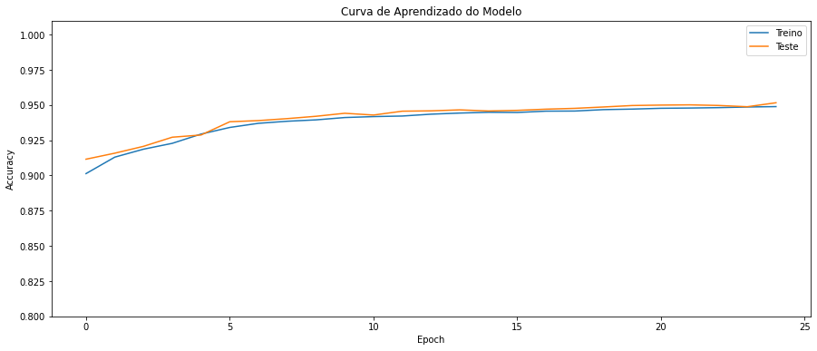

```python
# Plot model performance
curva_aprendizado(modelo_cnn_satelite.history)
```

The model has great performance and learning was slow. We could increase the learning rate a little bit and train longer in order to increase the accuracy even more.

## Training Results and Image Classification

```python
# The y_test item has all the predictions in the test data for each fold of the cross validation
len(y_teste)
```

```
5
```

```python
# Create an array for results of one CV fold
resultado = np.array(y_teste[0])
```

```python
# View fold results
resultado
```

```
array([[3.58537026e-02, 1.15087430e-03, 2.74071121e-03, ...,
        1.06197447e-02, 1.62826444e-03, 4.93933558e-02],
       [6.93802312e-02, 1.10839121e-03, 1.89726776e-03, ...,
        1.71465091e-02, 1.46847568e-03, 4.84707914e-02],
       [1.15033634e-01, 1.32205756e-03, 2.07197107e-03, ...,
        7.18102601e-05, 1.11096841e-03, 9.87202600e-02],
       ...,
       [1.28187209e-01, 3.08408635e-04, 5.84577210e-04, ...,
        1.44266465e-04, 6.78103126e-04, 9.32235867e-02],
       [9.32165861e-01, 1.80980866e-03, 2.02542841e-02, ...,
        5.01354458e-03, 1.23906862e-02, 1.58686966e-01],
       [5.99018559e-02, 6.51527080e-04, 3.68372235e-03, ...,
        6.84326887e-03, 1.73138711e-03, 9.66413543e-02]], dtype=float32)
```

```python
# Convert array to dataframe and preview result
resultado_df = pd.DataFrame(resultado, columns = labels)
resultado_df.head()
```

|  | agriculture | artisinal_mine | bare_ground | blooming | blow_down | clear | cloudy | conventional_mine | cultivation | habitation | haze | partly_cloudy | primary | road | selective_logging | slash_burn | water |
| --- | --- | --- | --- | --- | --- | --- | --- | --- | --- | --- | --- | --- | --- | --- | --- | --- | --- |
| 0 | 0.035854 | 0.001151 | 0.002741 | 3.312169e-02 | 0.004185 | 0.982465 | 0.000044 | 0.000278 | 0.023750 | 0.005646 | 0.000627 | 0.013735 | 0.999645 | 0.023195 | 0.010620 | 0.001628 | 0.049393 |
| 1 | 0.069380 | 0.001108 | 0.001897 | 2.924577e-02 | 0.007014 | 0.902134 | 0.000004 | 0.000149 | 0.065861 | 0.009277 | 0.000077 | 0.106229 | 0.999982 | 0.030755 | 0.017147 | 0.001468 | 0.048471 |
| 2 | 0.115034 | 0.001322 | 0.002072 | 1.965914e-05 | 0.000094 | 0.001064 | 0.016263 | 0.000399 | 0.030340 | 0.010436 | 0.000264 | 0.976215 | 0.983666 | 0.075785 | 0.000072 | 0.001111 | 0.098720 |
| 3 | 0.017205 | 0.000190 | 0.000708 | 1.400888e-02 | 0.000946 | 0.980363 | 0.000010 | 0.000054 | 0.012234 | 0.002051 | 0.000106 | 0.016535 | 0.999901 | 0.010341 | 0.003278 | 0.000325 | 0.023448 |
| 4 | 0.054526 | 0.000048 | 0.000135 | 9.120800e-08 | 0.000002 | 0.000796 | 0.420501 | 0.000011 | 0.005659 | 0.007255 | 0.000865 | 0.568739 | 0.532211 | 0.034072 | 0.000003 | 0.000026 | 0.078662 |

```python
# Shape
resultado_df.shape
```

```
(40479, 17)
```

In the table above, each row is an image and each column is a class. Each column represents the class score for that image. All this for 1 single fold.

Let's calculate the average of the results obtained from the cross validation with k (5) folds.

```python
# Loop to fill the array
for i in range(1, NFOLDS):
    resultado += np.array(y_teste[i])
    resultado /= NFOLDS
```

```python
# Convert array to dataframe
resultado_df_final = pd.DataFrame(resultado, columns = labels)
resultado_df_final.head()
```

|  | agriculture | artisinal_mine | bare_ground | blooming | blow_down | clear | cloudy | conventional_mine | cultivation | habitation | haze | partly_cloudy | primary | road | selective_logging | slash_burn | water |
| --- | --- | --- | --- | --- | --- | --- | --- | --- | --- | --- | --- | --- | --- | --- | --- | --- | --- |
| 0 | 0.017726 | 0.000241 | 0.001418 | 0.007395 | 0.002265 | 0.245403 | 0.000015 | 0.000047 | 0.013692 | 0.001906 | 0.000832 | 0.004331 | 0.251142 | 0.006566 | 0.002542 | 0.000602 | 0.021365 |
| 1 | 0.025142 | 0.000216 | 0.000907 | 0.015320 | 0.006049 | 0.243286 | 0.000001 | 0.000024 | 0.037599 | 0.003390 | 0.000075 | 0.010230 | 0.251197 | 0.006217 | 0.006709 | 0.001237 | 0.018200 |
| 2 | 0.049017 | 0.000511 | 0.001105 | 0.000022 | 0.000167 | 0.000125 | 0.000939 | 0.000391 | 0.034046 | 0.002138 | 0.000080 | 0.249998 | 0.249673 | 0.015629 | 0.000184 | 0.000667 | 0.039647 |
| 3 | 0.020377 | 0.000238 | 0.000840 | 0.009568 | 0.001577 | 0.188609 | 0.000002 | 0.000036 | 0.017641 | 0.001785 | 0.000045 | 0.081648 | 0.251196 | 0.008114 | 0.003946 | 0.000404 | 0.016709 |
| 4 | 0.031166 | 0.000176 | 0.000720 | 0.000010 | 0.000020 | 0.001138 | 0.109564 | 0.000060 | 0.009219 | 0.003895 | 0.001106 | 0.164217 | 0.146160 | 0.014621 | 0.000057 | 0.000089 | 0.025342 |

## Saving and Displaying Final Result

```python
# Saving the predictions
resultado_df_final.to_csv(PATH_ARQUIVOS + 'resultado_previsoes.csv')
```

```python
# Recording predictions and suggested classes in testing

# List for predictions
preds = []

# Loop to extract predictions
for i in range(resultado_df_final.shape[0]):
    a = resultado_df_final.iloc[[i]]
    a = a.apply(lambda x: x > THRES, axis = 1)
    a = a.transpose()
    a = a.loc[a[i] == True]
    ' '.join(list(a.index))
    preds.append(' '.join(list(a.index)))
```

```python
# Recording the original labels and model predictions in csv format
# This is the file I'll submit to Kaggle
dados_teste_final['preds'] = preds
dados_teste_final.to_csv(PATH_ARQUIVOS + 'resultado_final.csv', index = False)
```

```python
# Viewing 20 model predictions
dados_teste_final.head(20)
```

|  | image_name | tags | preds |
| --- | --- | --- | --- |
| 0 | test_0.jpg | [primary, clear, agriculture, road, water] | clear primary |
| 1 | test_1.jpg | [primary, clear, agriculture, road, water] | clear primary |
| 2 | test_2.jpg | [primary, clear, agriculture, road, water] | partly_cloudy primary |
| 3 | test_3.jpg | [primary, clear, agriculture, road, water] | primary |
| 4 | test_4.jpg | [primary, clear, agriculture, road, water] |  |
| 5 | test_5.jpg | [primary, clear, agriculture, road, water] | clear primary |
| 6 | test_6.jpg | [primary, clear, agriculture, road, water] | primary |
| 7 | test_7.jpg | [primary, clear, agriculture, road, water] | clear habitation road |
| 8 | test_8.jpg | [primary, clear, agriculture, road, water] | clear primary |
| 9 | test_9.jpg | [primary, clear, agriculture, road, water] | primary |
| 10 | test_10.jpg | [primary, clear, agriculture, road, water] | partly_cloudy primary |
| 11 | test_11.jpg | [primary, clear, agriculture, road, water] | clear primary |
| 12 | test_12.jpg | [primary, clear, agriculture, road, water] | cloudy |
| 13 | test_13.jpg | [primary, clear, agriculture, road, water] | clear primary |
| 14 | test_14.jpg | [primary, clear, agriculture, road, water] | clear primary |
| 15 | test_15.jpg | [primary, clear, agriculture, road, water] | clear primary |
| 16 | test_16.jpg | [primary, clear, agriculture, road, water] | agriculture clear primary road |
| 17 | test_17.jpg | [primary, clear, agriculture, road, water] | primary |
| 18 | test_18.jpg | [primary, clear, agriculture, road, water] | primary |
| 19 | test_19.jpg | [primary, clear, agriculture, road, water] | clear primary |

# End

Matheus Schmitz  
[LinkedIn](https://www.linkedin.com/in/matheusschmitz/)  
[Github Portfolio](https://matheus-schmitz.github.io/)